# ST 431/531: Sampling Methods

One Stage Cluster Sampling

Week 5

# Lecture 1

## Outline

- Introduction
- When to use cluster sampling
- One-stage cluster sampling with clusters of equal size
- Theory
- Efficiency

## Cluster Sampling

We’ve seen some cases where there are different ways of listing the sampling units.

Maybe we want to know how many cars are owned by residents of a city, but we could only take a sample of households, or buildings, or city blocks.

Until now, the **sampling unit** and the **observational unit** have been the same thing.

If it’s not feasible that the sampling frame lists all observational units in the population, may need to use cluster sampling.

## Cluster Sampling - Examples

May have a list of all dairy farms, but not all cows on dairy farms.

Instead of obtaining a list of all students in a dorm building and taking a SRS, sample suites and then ask every person in the selected suites.

The U.S. Census Bureau often uses city blocks as clusters of households or people. They report block statistics, including total population, racial mix, dollar value of property, percent ownership, etc. These block statistics are used by market research firms, who may want to estimate potential market for a product, potential sales if a new store were to open, etc.

## Why Use Cluster Sampling?

- Constructing a sampling frame may be difficult, expensive, or impossible. (For example, we don’t have a list of all plants in all gardens in a city, but we do have a list of gardens.)
- The population may be widely distributed geographically or may occur in natural clusters where it is less expensive to take a sample of clusters rather than a sample of individuals.

## Cluster Sampling vs. Stratified Sampling

A **cluster**, like a stratum, is a grouping of members of the population. Each element of the population belongs to exactly one cluster.

In stratified sampling, an independent SRS was taken from EVERY stratum.

In cluster sampling, an SRS of clusters is taken. (In one-stage cluster sampling, all elements within selected clusters are observed. In two-stage cluster sampling, sampling is done within selected clusters.)

## Cluster vs. Stratified Sampling

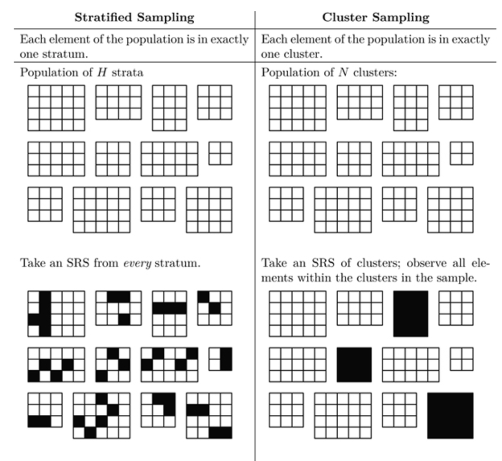

Four panels are shown. Each has 12 different groups of grid cells of different sizes. The top two panels show the population of H strata (left) and N clusters (right), which are identical. The bottom left panel shows a SRS from every stratum, where a few (but not all) of the grid cells are shaded in for every group of grid cells. The bottom right panel shows a SRS of clusters, where 3 of the 12 groups of grid cells are completely shaded in and the rest have no shading.

## Cluster Sampling vs. Stratified Sampling

Generally speaking, stratified sampling estimates tend to have *lower variance* than SRS estimates, and cluster sampling estimates tend to have *higher variance* than SRS estimates.

In stratified sampling, the variance of the estimate of $\bar{y}_\mathcal{U}$ depends on the variance of values within strata. The greatest precision occurs when elements within strata are homogeneous, and stratum means differ as much as possible.

In cluster sampling, the variance of the estimate of $\bar{y}_\mathcal{U}$ depends primarily on the variance between cluster means. It also decreases as we sample more clusters. The greatest precision occurs when elements within clusters are heterogeneous, and cluster means are similar to one another.

## Sampling Units

The **primary sampling unit (psu)** is a cluster.

The **secondary sampling unit (ssu)** is an element of a cluster.

(We could have more levels of clustering, but for this class we will stick with a maximum of 2.)

## Example: Sample of Food in Pantry

Consider a sample of 3 food items in your pantry.

The population is all food items in your pantry. We are interested in estimating the average number of vowels in the name of an item.

Each of you is a psu (cluster).

The items of food are the ssus.

On each food item, we measure $y_{ij}=\#\text{vowels in food name}$.

## Some Quick Notation

$\mathcal{U}$ is the population of $N$ psus (clusters).

$\mathcal{S}$ is the sample of psus chosen.

$\mathcal{S}_i$ is the sample of ssus chosen from the $i$th psu.

$y_{ij}$ is the measurement for $j$th element in $i$th psu.

- There are $N$ psus in the population, and $n$ in the sample.
- There are $M_i$ ssus in psu $i$ in the population. There are $m_i$ ssus in psu $i$ in the sample.

## One-Stage Cluster Sampling

In a **one-stage cluster sample**, either all or none of the elements that compose a cluster (psu) are in the sample.

Example: Sample classrooms, and then give questionnaire to every student in selected classrooms.

Simplest design: take a SRS of $n$ psus from the population and measure the response for every element in samples psus.

Therefore, $M_i=m_i$.

## Example

Take a SRS of clusters, measure every element within the selected clusters.

| Cluster A | *Cluster B* | Cluster C | Cluster D | *Cluster E* |
| --- | --- | --- | --- | --- |
| 4 | *3* | 2 | 0 | *1* |
| 6 | *2* | 4 | 8 | *3* |
| 5 | *4* |  | 2 | *10* |
| 8 | *9* |  | 8 |  |
| 2 | *3* |  | 2 |  |
| 1 |  |  | 5 |  |
| 4 |  |  |  |  |

This example has clusters of *different* sizes.

## Clusters of Equal Size

Suppose a one-stage cluster sample where each psu has the same number of elements.

Then $M_i=m_i=M$.

Simple and fairly unrealistic, but there are some examples where this is true.

*Example*: Population of gallon jugs of milk. Want to estimate the total number of bacteria. Crates consist of 4 jugs each. The crates are the psus and the gallon jugs are the ssus. $N=\#\text{crates}$, $M=4$.

## Cluster Total $t_i$

Take a SRS of $n$ psus and observe every element of the psu. For each psu we can calculate the total of the $M$ elements. Call this $t_i$ for psu $i$.

$$t_i=\sum_{j=1}^M y_{ij}$$

Example: $t_i$ is the total number of bacteria in crate $i$. In one-stage cluster sampling, we observe $t_i$. In two-stage cluster sampling (later) we have to estimate it.

## Estimating a Total for Clusters of Equal Size

If we observed all clusters, we could exactly calculate the population total,
$$t=\sum_{i=1}^N t_i=\sum_{i=1}^N \sum_{j=1}^M y_{ij}$$

But we have only a sample of clusters, so we can estimate the population total $t$ by
$$\hat{t}=\frac{N}{n}\sum_{i\in\mathcal{S}}t_i=\frac{N}{n}\sum_{i\in\mathcal{S}}\sum_{j=1}^{M}y_{ij}$$

This is the SRS estimator we are used to, except we have $M$ observational units per psu. (We would need to account for this if we were keeping track of measurement error, but we aren’t here.)

## Exact Variance of the Total Estimator

Because we had a SRS of $n$ units from a population of $N$ units (psus) and we observed every element of the psu, we can use the Chapter 2 results to show that $\hat{t}$ is an **unbiased** estimator of $t$.

The variance of the estimator is
$$V(\hat{t})=N^2\left(1-\frac{n}{N}\right)\frac{S_t^2}{n}$$
where the population variance of the psu totals is
$$S_t^2=\frac{1}{N-1}\sum_{i=1}^N\left(t_i-\frac{t}{N}\right)^2$$

## Estimated Variance of the Total Estimator

Estimate $S_t^2$ using $s_t^2$ where
$$s_t^2=\frac{1}{n-1}\sum_{i\in\mathcal{S}}\left(t_i-\frac{\hat{t}}{N}\right)^2$$
so
$$\hat{V}(\hat{t})=N^2\left(1-\frac{n}{N}\right)\frac{s_t^2}{n}$$

## Estimating a Mean for Clusters of Equal Size

To estimate the population mean $\bar{y}_\mathcal{U}$ instead of the population total $t$, divide the estimated total by the number of elements ( $NM$ ):

$$\begin{align*}
\hat{\bar{y}}&=\frac{\hat{t}}{NM} = \frac{1}{nM}\sum_{i\in\mathcal{S}}t_i \\
V(\hat{\bar{y}})&=\frac{1}{N^2M^2}V(\hat{t}) \\
&= \left(1-\frac{n}{N}\right)\frac{S_t^2}{nM^2} \\
\hat{V}(\hat{\bar{y}})&=\left(1-\frac{n}{N}\right)\frac{s_t^2}{nM^2}
\end{align*}$$

## Review

In a *one-stage* cluster sample, we take a SRS of clusters (psus) and then observe every unit in the clusters.

This means that cluster means or totals are known *exactly* for the sampled clusters (they do not have to be estimated). We can use this one number (e.g., $t_i$ for cluster $i$) in the same SRS estimators we are used to from Chapter 2.

# Some Theory

## Clusters of Equal Size - Theory

The variance of $\hat{t}$ and $\hat{\bar{y}}$ are driven by the variance *between* clusters.

Let $\bar{y}_{i\mathcal{U}}=\frac{t_i}{M}$ be the population mean in cluster $i$.

Then we can write the population variance of the psus as

$$\begin{align*}
S_t^2&=\frac{1}{N-1}\sum_{i=1}^N \left(t_i-\frac{t}{N}\right)^2 \\
&= \frac{1}{N-1}\sum_{i=1}^N \left(M\bar{y}_{i\mathcal{U}}-\frac{NM\bar{y}_\mathcal{U}}{N}\right)^2 \\
&= \frac{M}{N-1}\underbrace{\sum_{i=1}^N M\left(\bar{y}_{i\mathcal{U}}-\bar{y}_\mathcal{U}\right)^2}_{\substack{\text{Between-group SS} \\ \text{in balanced one-way ANOVA}}} \\
\end{align*}$$

## Relationship to ANOVA

| Source of Variation | Sum of Squares | Notes |
| --- | --- | --- |
| Between group | $SSB$ | Want small in cluster sampling |
| Within group | $SSW$ | Want small in stratified sampling |
| Total | $SST$ | Fixed for a given population |

Since $SST$ is fixed, larger $SSB$ $\Leftrightarrow$ smaller $SSW$.

## Intraclass Correlation Coefficient (ICC)

We can measure homogeneity within clusters using the **intraclass correlation coefficient** (**ICC**).

$$\text{ICC}=1-\frac{M}{M-1}\frac{SSW}{SST}$$

This is the Pearson correlation coefficient of pairs of $y_{ij}$’s within the same cluster. The max ICC is 1.

The ICC is close to 1 when $\frac{SSW}{SST}$ is close to 0, and so SSB is large.

This means that between-cluster variability is high, so the variance of the clustering estimators will be large.

## Values of ICC

If clusters occur naturally in the population, the ICC is usually *positive*. Elements within the same cluster tend to be more similar than elements selected at random from the population.

The ICC is *negative* if elements within a cluster are dispersed more than a randomly chosen group would be. This forces the cluster means to be very nearly equal. If ICC $<$ 0, cluster sampling is more efficient than simple random sampling of elements. But this rarely happens in naturally occurring clusters.

## Efficiency

To compare designs, we use the idea of **efficiency**: the ratio of the variance of the estimators.

$$\begin{align*}
V(\hat{t}_\text{SRS}) &= (NM)^2 \left(1-\frac{nM}{NM}\right)\frac{S^2}{nM} \\
&= (NM)^2\left(1-\frac{nM}{NM}\right)\frac{SST}{nM(NM-1)} \\
V(\hat{t}_\text{clust}) &= N^2\left(1-\frac{n}{N}\right)\frac{S_t^2}{n}\\
&=N^2\left(1-\frac{n}{N}\right)\frac{M(SSB)}{n(N-1)}
\end{align*}$$

## Efficiency

$$\begin{align*}
\frac{V(\hat{t}_\text{clust})}{V(\hat{t}_\text{SRS})} &= \frac{N^2\left(1-\frac{n}{N}\right)\frac{M(SSB)}{n(N-1)}}{(NM)^2\left(1-\frac{nM}{NM}\right)\frac{SST}{nM(NM-1)}} \\
&\\
&= \frac{NM-1}{N-1}\frac{SSB}{SST} \\
&\\
&= \frac{NM-1}{M(N-1)}[1+(M-1)\text{ICC}]
\end{align*}$$

## Efficiency

$$\frac{V(\hat{t}_\text{clust})}{V(\hat{t}_\text{SRS})} =\frac{NM-1}{M(N-1)}[1+(M-1)\text{ICC}]$$

The **efficiency** measures how many ssus in cluster sampling each ssu in a SRS is worth.

*Example*: Assuming large $N$, $\frac{NM-1}{M(N-1)}\approx 1$. In this case, if ICC=0.5 and $M=5$, then $1+(M-1)\text{ICC}=3$, so we would need to measure 300 elements using a cluster sample to obtain the same precision as an SRS of 100 elements.

If the ICC is close to 1, SRS estimate will be much more efficient.

## Clusters of Equal Size - Theory

With cluster sampling, we likely need to sample more elements to get the same precision as an SRS.

But the hope is that with cluster sampling, the cost per observation will be much lower, so overall the sample may be cheaper.

# Lecture 2

## Outline

- One-Stage Cluster Sampling with Clusters of Unequal Size
  - Unbiased estimators
  - Ratio estimators
- Sampling Weights
- Examples

## Clusters of Unequal Size - Totals

In social surveys, clusters are rarely the same size.

An *unbiased* estimator of $t$ is the same as before:

$$\begin{align*}
\hat{t}_\text{unb} &= \frac{N}{n} \sum_{i\in\mathcal{S}}t_i \\
\hat{V}(\hat{t}_\text{unb}) &= N^2\left(1-\frac{n}{N}\right) \frac{s_t^2}{n}
\end{align*}$$

## Clusters of Unequal Size - Totals

*Key difference*: for unequal-sized clusters, $t_i$ will likely vary a lot, so $s_t^2=\frac{1}{n-1}\sum\limits_{i\in\mathcal{S}}\left(t_i-\frac{\hat{t}}{N}\right)^2$ likely will be large.

Often, $s_t^2$ is larger in a cluster sample when the psus have unequal sizes than when the psus all have the same number of ssus.

## Example Population

If whole population was known:

| A | B | C | D | E |
| --- | --- | --- | --- | --- |
| 4 | 3 | 2 | 0 | 1 |
| 6 | 2 | 4 | 8 | 3 |
| 5 | 4 |  | 2 | 10 |
| 8 | 9 |  | 8 |  |
| 2 | 3 |  | 2 |  |
| 1 |  |  | 5 |  |
| 4 |  |  |  |  |

$$\begin{align*}
&N = 5 \\
&M_1 = 7, M_2=5, M_3=2, M_4=6, M_5=3 \\
&M_0 = 23 \\
&t_1 = 30, t_2=21, t_3=6, t_4=25, t_5=14 \\
&t = 96
\end{align*}$$

## Example One-Stage Cluster Sample

For the sample highlighted:

| A | *B* | C | D | *E* |
| --- | --- | --- | --- | --- |
| ? | *3* | ? | ? | *1* |
| - | *2* | - | - | *3* |
|  | *4* |  |  | *10* |
|  | *9* |  |  |  |
|  | *3* |  |  |  |

$$\begin{align*}
&N=5\\
&n = 2\\
&m_2 = 5, m_5=3 \\
&t_2 = 21, t_5=14 \\
&\hat{t}_\text{unb} = \frac{5}{2}(21 + 14) = 87.5
\end{align*}$$

## Clusters of Unequal Size - Means

Define the total number of ssus in the population:
$$M_0=\sum_{i=1}^N M_i$$

(In the clusters of equal size case, this is what $NM$ was.)

Then

$$\begin{align*}
\hat{\bar{y}}_\text{unb}&=\frac{\hat{t}_\text{unb}}{M_0} \\
\hat{V}(\hat{\bar{y}}_\text{unb}) &= \frac{\hat{V}(\hat{t}_\text{unb})}{M_0^2}
\end{align*}$$

## Clusters of Unequal Size

The unbiased estimators of the total $\hat{t}_\text{unb}$ and mean $\hat{\bar{y}}_\text{unb}$ can be inefficient [*high variance*] when the values of $M_i$ are unequal since they depend on the variability of the cluster totals $t_i$.

$M_0$ may also be unknown.

But we have ratio estimation!

## Clusters of Unequal Size - Ratio Estimation

We usually expect $t_i$ to be positively correlated with $M_i$ (larger clusters will have larger totals).

We can view the population mean as a ratio:
$$\bar{y}_\mathcal{U}=\frac{\sum_{i=1}^N t_i}{\sum_{i=1}^N M_i}=\frac{t}{M_0}$$

Now our outcome of interest ( $y$ in ratio terminology) is $t_i$ and our auxiliary variable ( $x$ ) is $M_i$, and $\bar{y}_\mathcal{U}=B$.

## Clusters of Unequal Size - Ratio Estimation of Mean

A *ratio* estimate for the population mean is then
$$\hat{\bar{y}}_r=\frac{\hat{t}_\text{unb}}{\hat{M}_0}=\frac{\sum\limits_{i\in\mathcal{S}}t_i}{\sum\limits_{i\in\mathcal{S}}M_i}=\frac{\sum\limits_{i\in\mathcal{S}}M_i\bar{y}_i}{\sum\limits_{i\in\mathcal{S}}M_i}$$

The denominator $\hat{M}_0$ is a *random* quantity that depends on which particular psus are included in the sample.

## Variance of the Ratio Estimator

The variance of the ratio estimator is

$$\begin{align*}
\hat{V}(\hat{\bar{y}}_r) &= \left(1-\frac{n}{N}\right)\frac{1}{n\bar{M}^2}\frac{\sum\limits_{i\in\mathcal{S}}(t_i-\hat{\bar{y}}_rM_i)^2}{n-1} \\
&= \left(1-\frac{n}{N}\right)\frac{1}{n\bar{M}^2}\frac{\sum\limits_{i\in\mathcal{S}}M_i^2(\bar{y}_i-\hat{\bar{y}}_r)^2}{n-1}
\end{align*}$$

This variance can be much smaller than that of the unbiased estimator $\hat{\bar{y}}_\text{unb}$.

## Clusters of Unequal Size - Ratio Estimation of Total

If we want to estimate a total using ratio estimation, we need to know $M_0$. Then the estimate is simply

$$\begin{align*}
\hat{t}_r &= M_0\hat{\bar{y}}_r \\
\hat{V}(\hat{t}_r) &= M_0^2 \hat{V}(\hat{\bar{y}}_r)
\end{align*}$$

If we don’t know $M_0$, we can’t use ratio estimation, but we could use the unbiased estimator.

## Estimator Summary (1)

### $M_0$ known:

[output not shown]

## Estimator Summary (2)

### $M_0$ not known:

[output not shown]

Note that the formulas shown are the same as the previous slide in instances where estimates can be found.

## One-Stage Cluster Sampling - Weights

The probability a psu is in the sample is $n/N$ since a SRS of $n$ of $N$ psus is taken.

Since it is a one-stage design, the probability a ssu is included in the sample given that the psu it is in was selected is 1. So
$$w_{ij}=\frac{N}{n}$$

One-stage cluster sampling thus produces a self-weighting sample when the psus are selected via SRS.

## Example of One-Stage, Unequal Cluster Size (Continued)

For the sample highlighted in orange:

| A | *B* | C | D | *E* |
| --- | --- | --- | --- | --- |
| ? | *3* | ? | ? | *1* |
|  | *2* |  |  | *3* |
|  | *4* |  |  | *10* |
|  | *9* |  |  |  |
|  | *3* |  |  |  |

$$\begin{align*}
&N=5\\
&n = 2\\
&m_2 = M_2=5, m_5=M_5=3 \\
&t_2 = 21, t_5=14 \\
&\hat{t}_\text{unb} = \frac{N}{n}\sum_{i\in\mathcal{S}}t_i=\frac{5}{2}(21 + 14) = 87.5
\end{align*}$$

## Example of One-Stage, Unequal Cluster Size (Continued)

| A | *B* | C | D | *E* |
| --- | --- | --- | --- | --- |
| ? | *3* | ? | ? | *1* |
|  | *2* |  |  | *3* |
|  | *4* |  |  | *10* |
|  | *9* |  |  |  |
|  | *3* |  |  |  |

## Another Example

A sociologist wants to estimate the per-capita income in a certain small city. No list of resident adults is available. Clusters are city blocks, numbered from 1 to 415. The sociologist has enough money to sample $n=3$ clusters and to interview every household within each cluster. Data are in the table.

> Estimate the per-capita income in the city and find the standard error of your estimate.

| Cluster | # Residents, $M_i$ | Total income per cluster, $y_i$ |
| --- | --- | --- |
| 1 | 8 | $96,000 |
| 2 | 12 | $120,000 |
| 3 | 4 | $42,000 |

## Another Example (Continued)

We don’t know $M_0$, the total number of adult residents, so we use ratio estimation.

$$\begin{align*}
\hat{\bar{y}}_r &= \frac{\sum_{i\in\mathcal{S}}t_i}{\sum_{i\in\mathcal{S}}M_i} \\
&= \frac{96000 + 120000 + 42000}{8 + 12 + 4} = 10750\\
& \\
\text{SE}(\hat{\bar{y}}_r) &= \sqrt{\left(1-\frac{n}{N}\right)\frac{1}{n\bar{M}^2}\frac{\sum_{i\in\mathcal{S}}(t_i-\hat{\bar{y}}_rM_i)^2}{n-1}} \\
&= \sqrt{\left(1-\frac{3}{415}\right)\frac{1}{3(8^2)}\frac{(96000-10750(8))^2+\cdots+(42000-10750(4))^2}{3-1}} \\
&= 685.9534
\end{align*}$$